# public data GO analysis

I have downloaded, mapped and counted reads over genes for 373 public RNA seq datasets. There are 2 biological replicates for each sample. The processing is detailed in a google drive markdown document https://drive.google.com/open?id=1mT7xdzzMvhn3HX5joY7xB5opygs2IZPr

The files SRRxxx_SRRxxx_counts_z_scores.txt_with_gene_name.txt contain all the genes (that had counts), so around 20,000 genes. For each gene there is a quantitated value per sample, along with a z score, p-value and absolute z-score. The z-scores and p-values have been calculated using an R script that runs the intensity difference test from SeqMonk and gives each gene a z-score depending on it’s position in the distribution.

1. Take the top 200 different genes and run them through a GO analysis.
2. Take genes that have a z-score higher than a certain threshold and re-run with these.

`for i in SRR*gene_name.txt; do head -n 201 $i | cut -f1 - | tail -n 200 > ${i}_top_200.txt; done rename _counts_z_scores.txt_with_gene_name.txt_top_200.txt _top_200.txt *top_200.txt`

```r
library("devtools")
load_all("C:/Users/bigginsl/Documents/GOcategoryStats")
```

```
## Loading GOcategoryStats
```

## The 200 genes from each pair of samples that have the highest z-scores

```r
files <- list.files(path = "D:/projects/biases/public_data/top_200", pattern = "top_200.txt", full.names = TRUE)
top200 <- lapply(files, function(x) scan(x, what = "character"))
```

There are 373 sets of genes here so I don’t want to examine each of the gene lists. I’ll run them through a GO overrepresentation analysis.

```r
go_results <- overrep_test(all_go_categories, top200[[1]], bg_genes)
head(go_results)

all_go_results <- lapply(top200, function(query){
  overrep_test(all_go_categories, query, bg_genes)
  })

save(all_go_results, file = "D:/projects/biases/public_data/all_go_results.rda")
# took 7-8 mins to run for 373 datasets so I'm saving the file rather than
# re-running this every time it gets knitted.
```

```r
load("D:/projects/biases/public_data/all_go_results.rda")
all_sig_categories <- unlist(sapply(all_go_results, rownames))
tabled_categories <- table(all_sig_categories)
ordered_categories <- tabled_categories[order(tabled_categories, decreasing = TRUE)]
filename <- paste0("GO_summary_", length(top200), "_datasets.txt" )
write.table(x = ordered_categories, filename, quote = FALSE, row.names = FALSE, sep = "\t")
```

Now we could do with some stats to pick a cutoff for the number of times a category appears. Let’s just select an arbitrary value of 50 for now….

## Create a dataset that contains these suspect set of categories

```r
suspects_top200 <- ordered_categories[ordered_categories >= 50]

# convert to proportions
suspects1 <- signif(suspects_top200/length(top200), digits = 2)

suspects1
```

```
## all_sig_categories
##                                                                                 NEGATIVE REGULATION OF BIOLOGICAL PROCESS%GOBP%GO:0048519
##                                                                                                                                      0.57
##                                                                                                     DEVELOPMENTAL PROCESS%GOBP%GO:0032502
##                                                                                                                                      0.55
##                                                                                          ANATOMICAL STRUCTURE DEVELOPMENT%GOBP%GO:0048856
##                                                                                                                                      0.55
##                                                                                   NEGATIVE REGULATION OF CELLULAR PROCESS%GOBP%GO:0048523
##                                                                                                                                      0.54
##                                                                                                      EXTRACELLULAR REGION%GOCC%GO:0005576
##                                                                                                                                      0.54
##                                                                                                 EXTRACELLULAR REGION PART%GOCC%GO:0044421
##                                                                                                                                      0.54
##                                                                                        MULTICELLULAR ORGANISM DEVELOPMENT%GOBP%GO:0007275
##                                                                                                                                      0.54
##                                                                                        REGULATION OF RESPONSE TO STIMULUS%GOBP%GO:0048583
##                                                                                                                                      0.54
##                                                                            REGULATION OF MULTICELLULAR ORGANISMAL PROCESS%GOBP%GO:0051239
##                                                                                                                                      0.53
##                                                                                                        SYSTEM DEVELOPMENT%GOBP%GO:0048731
##                                                                                                                                      0.53
##                                                                                                       EXTRACELLULAR SPACE%GOCC%GO:0005615
##                                                                                                                                      0.53
##                                                                                   REGULATION OF PRIMARY METABOLIC PROCESS%GOBP%GO:0080090
##                                                                                                                                      0.51
##                                                                                                      CELL DIFFERENTIATION%GOBP%GO:0030154
##                                                                                                                                      0.50
##                                                                                  POSITIVE REGULATION OF METABOLIC PROCESS%GOBP%GO:0009893
##                                                                                                                                      0.50
##                                                                                                  ANIMAL ORGAN DEVELOPMENT%GOBP%GO:0048513
##                                                                                                                                      0.50
##                                                                                            CELLULAR DEVELOPMENTAL PROCESS%GOBP%GO:0048869
##                                                                                                                                      0.50
##                                                                                       REGULATION OF DEVELOPMENTAL PROCESS%GOBP%GO:0050793
##                                                                                                                                      0.50
##                                                                         REGULATION OF NITROGEN COMPOUND METABOLIC PROCESS%GOBP%GO:0051171
##                                                                                                                                      0.50
##                                                                                          REGULATION OF CELL PROLIFERATION%GOBP%GO:0042127
##                                                                                                                                      0.49
##                                                                                                REGULATION OF LOCALIZATION%GOBP%GO:0032879
```

[output cut: 924 more lines]

```
##                                                                                                                                      0.13
##                                                                                                        HYDROLASE ACTIVITY%GOMF%GO:0016787
##                                                                                                                                      0.13
##                                                                                     NEGATIVE REGULATION OF CELL MIGRATION%GOBP%GO:0030336
##                                                                                                                                      0.13
##                                                                       NEGATIVE REGULATION OF PROTEIN MODIFICATION PROCESS%GOBP%GO:0031400
##                                                                                                                                      0.13
##                                                                                                              PHAGOCYTOSIS%GOBP%GO:0006909
##                                                                                                                                      0.13
##                                                                                       REGULATION OF CELLULAR LOCALIZATION%GOBP%GO:0060341
##                                                                                                                                      0.13
##                                                                                                  REGULATION OF CHEMOTAXIS%GOBP%GO:0050920
##                                                                                                                                      0.13
##                                                                              REGULATION OF MONONUCLEAR CELL PROLIFERATION%GOBP%GO:0032944
##                                                                                                                                      0.13
```

```r
save(suspects1, file = "M:/GOcategoryStats/data/suspects1.rda")
```

Have a quick look at the genes in the top categories

```r
file_location <- "http://download.baderlab.org/EM_Genesets/current_release/Mouse/symbol/Mouse_GO_AllPathways_no_GO_iea_December_01_2018_symbol.gmt"

functional_categories <- process_GMT(file_location, max_genes = 20000)
which(names(functional_categories) %in% names(suspects1[1]))
```

```
## [1] 8235
```

```r
# Look up the genes from the category
# get the genes from the top category
top_cat <- get_GO_sets(names(suspects1)[1], functional_categories)
top_cat <- top_cat[[1]]

# plot lengths
#query_lengths <- get_lengths(query_filt, gene_info)

gene_info <- parse_GTF_info(m_musculus)
head(gene_info)
```

|  | chr | type | start | end | info | gene_name | length |
| --- | --- | --- | --- | --- | --- | --- | --- |
| 1 | 1 | gene | 3073253 | 3074322 | gene_id "ENSMUSG00000102693"; gene_version "1"; gene_name "4933401J01Rik"; gene_source "havana"; gene_biotype "TEC"; | 4933401J01RIK | 1069 |
| 2 | 1 | gene | 3102016 | 3102125 | gene_id "ENSMUSG00000064842"; gene_version "1"; gene_name "Gm26206"; gene_source "ensembl"; gene_biotype "snRNA"; | GM26206 | 109 |
| 3 | 1 | gene | 3205901 | 3671498 | gene_id "ENSMUSG00000051951"; gene_version "5"; gene_name "Xkr4"; gene_source "ensembl_havana"; gene_biotype "protein_coding"; | XKR4 | 465597 |
| 4 | 1 | gene | 3252757 | 3253236 | gene_id "ENSMUSG00000102851"; gene_version "1"; gene_name "Gm18956"; gene_source "havana"; gene_biotype "processed_pseudogene"; | GM18956 | 479 |
| 5 | 1 | gene | 3365731 | 3368549 | gene_id "ENSMUSG00000103377"; gene_version "1"; gene_name "Gm37180"; gene_source "havana"; gene_biotype "TEC"; | GM37180 | 2818 |
| 6 | 1 | gene | 3375556 | 3377788 | gene_id "ENSMUSG00000104017"; gene_version "1"; gene_name "Gm37363"; gene_source "havana"; gene_biotype "TEC"; | GM37363 | 2232 |

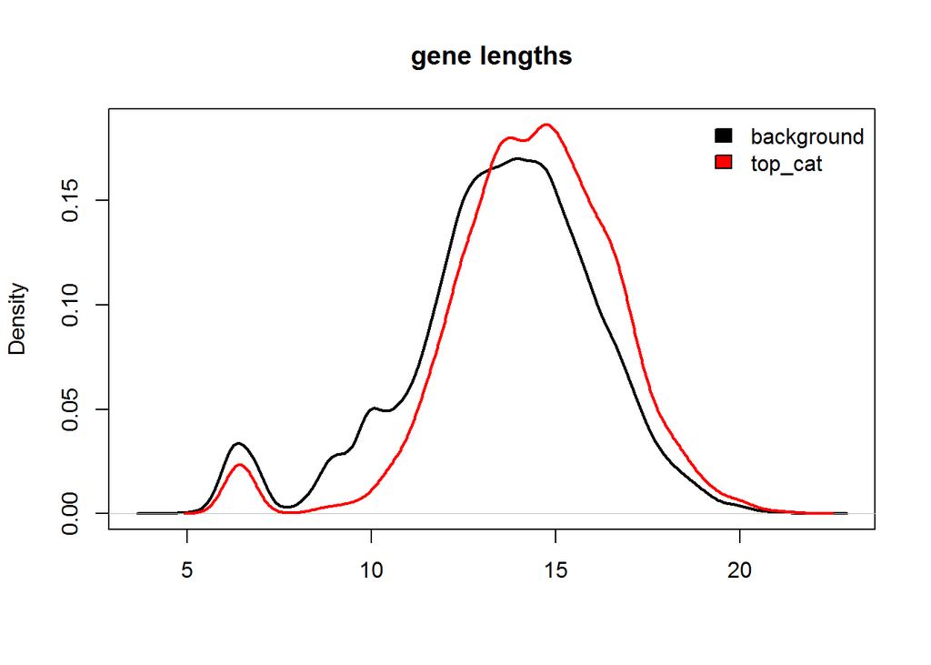

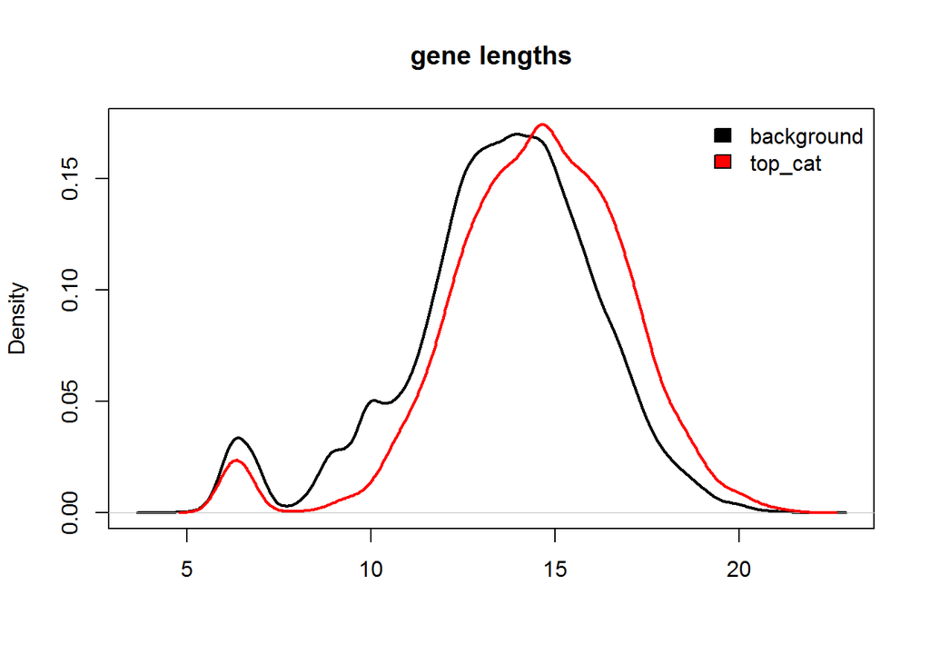

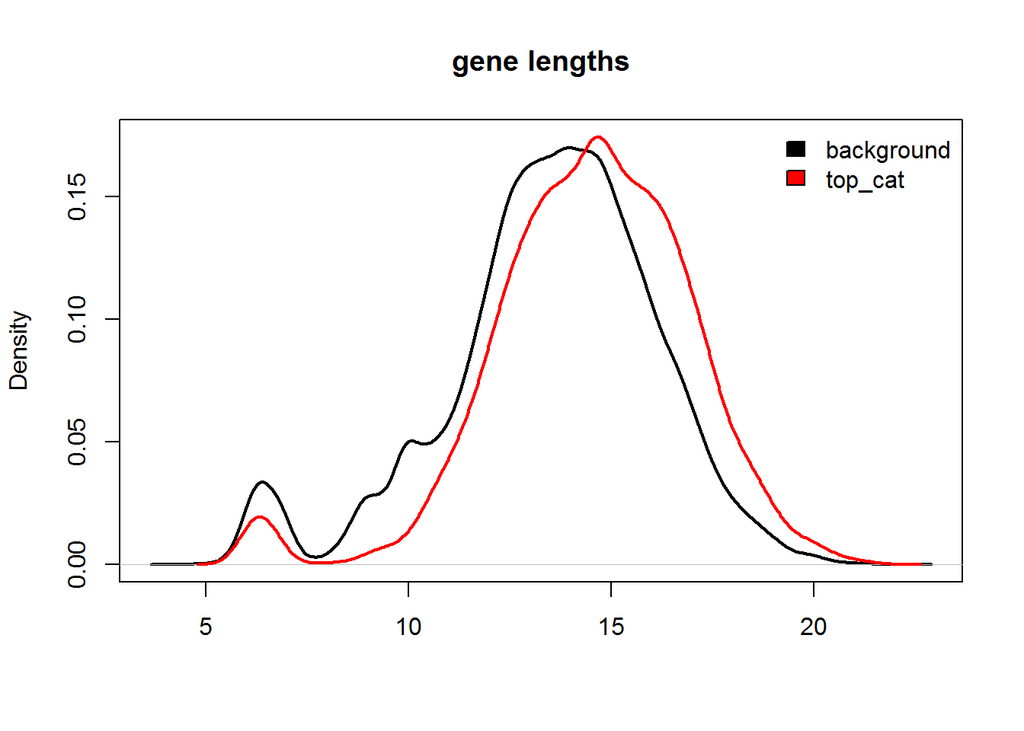

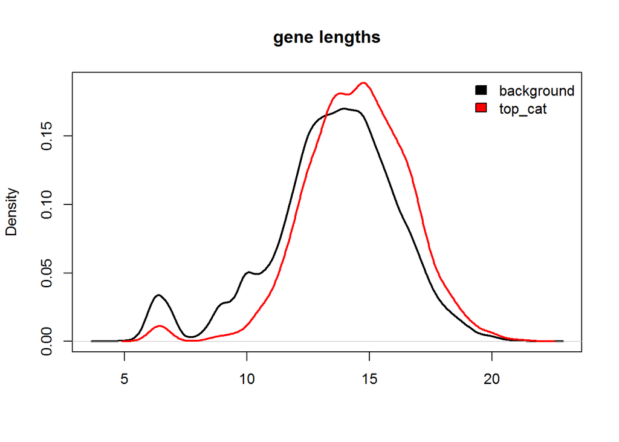

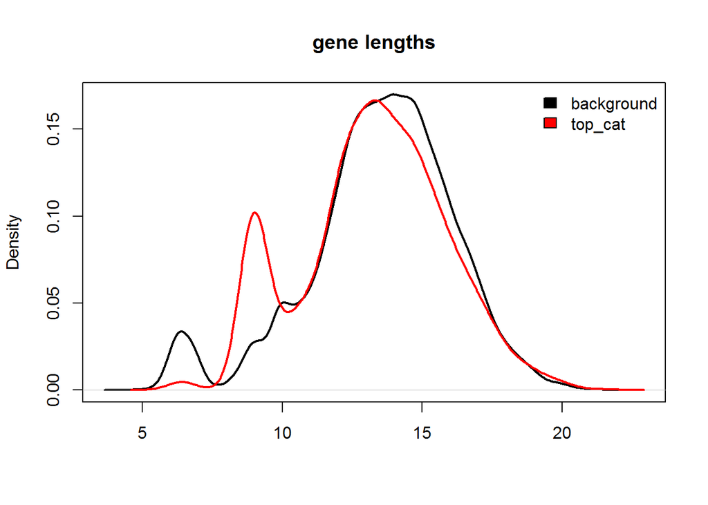

```r
bg_lengths <- get_lengths(bg_genes, gene_info)

top_cat_lengths <- get_lengths(top_cat, gene_info)

my_plotting_data <- list(background = bg_lengths, top_cat = top_cat_lengths)
density_plot(my_plotting_data, log = TRUE, main  = "gene lengths")


for (i in 1:5) {
  top_cat <- get_GO_sets(names(suspects1)[i], functional_categories)
  top_cat_lengths <- get_lengths(top_cat[[1]], gene_info)

  my_plotting_data <- list(background = bg_lengths, top_cat = top_cat_lengths)
  density_plot(my_plotting_data, log = TRUE, main  = "gene lengths")
}
```

[figure not shown]

```r
bg_chr <- get_chromosomes(bg_genes, gene_info)
top_cat_chr <- get_chromosomes(top_cat, gene_info)

chr_list <- list(background = bg_chr, top_cat = top_cat_chr)

chr_proportions <- get_chr_percentage(chr_list)

bar_plot(chr_proportions, main = "chr", col = topo.colors(ncol(chr_proportions), alpha = 0.5), cex_names = 0.6)
```

use awk to filter in unix `echo "" > z5.txt for i in *_gene_name.txt; do awk '$7>5 {print $1}' $i >> z5.txt ; done`

This would work in a different way as there could be wildly varying numbers of genes per dataset. This would be more of a case of getting a list of suspect genes rather than suspect categories, and then maybe generating a set of suspect categories from the genes.

```r
zfile <- "D:/projects/biases/public_data/top_zscores/z5.txt"
z5 <- scan(zfile, what = "character")

x_ordered <- table(z5)[order(table(z5), decreasing = TRUE)]


df <- data.frame(x_ordered)
colnames(df) <- c("gene_name", "count")
```